# Process Unispec Files

Ruby An

6/17/2019

## Required Packages

## R Functions

## Data directories, date and key files

- Session_date in yyyy-mm-dd form.
- data_path is year folder where the session files are stored. The structure is year/spu_orig/yyyy-mm-dd where yyyy-mm-dd is sample date. Should be on OneDrive.
- Field Key file with header “Date,Site,Block,Treatment,Replicate,Location,FileNum,Notes,Weather”. File name convention is year_unispec_field_key.csv

## Digitize Data Locally

### Read .SPU files

### Read Field Key

## Data Summary

Raw .spu files read-into spu_dataframe

| Date | Site | Files |
| --- | --- | --- |
| 2020-07-16 | MAT06 | 330 |

Files listed in field key

| Date | Site | Block | Treatments | Num_Files |
| --- | --- | --- | --- | --- |
| 2020-07-16 | MAT06 | B1 | CT,F0.5,F1,F10,F2,F5,GH-CT,GH-no-plastic | 80 |
| 2020-07-16 | MAT06 | B1, B2, B3, B4 | DARK,REF,REF-maxed,THROWAWAY | 10 |
| 2020-07-16 | MAT06 | B2 | CT,F0.5,F1,F10,F2,F5,GH-CT,GH-no-plastic | 80 |
| 2020-07-16 | MAT06 | B3 | CT,F0.5,F1,F10,F2,F5,GH-CT,GH-no-plastic | 80 |
| 2020-07-16 | MAT06 | B4 | CT,F0.5,F1,F10,F2,F5,GH-CT,GH-no-plastic | 80 |

## QAQC

### Missing files

List missing raw .spu files and those that are unprocessed (raw .spu file does not appear in summary .xlsx). Missing raw files

```
## character(0)
```

### Mis-Labeling

Check for human error in recording correspondance between metadata and file numbers.

#### Discrepancy Checks

Check for possiblem mislabeling:

Missing labels:

Large filenumbers:

An abnormal numbers of files per plot:

| Site | Date | Block | Treatments | Num_Files |
| --- | --- | --- | --- | --- |
| MAT06 | 2020-07-16 | B1, B2, B3, B4 | REF-maxed | 1 |

#### Duplicates

Identify duplicates in field key or spu_files. Fix by editing unispec_key_fix.csv or deleting duplicate files. Only duplicates should be REF files used for other sites.

```
## [1] TRUE
```

### Instrument Check:

wrong integration time, problems with the sensors, cables, etc.

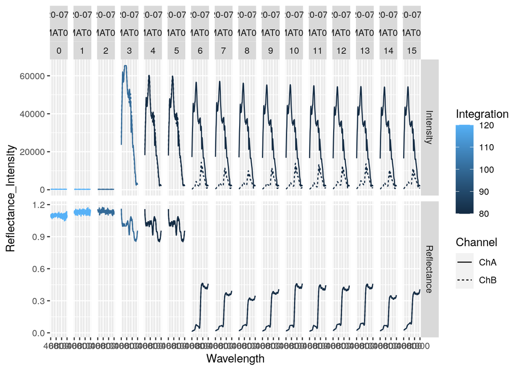

###### Max’d Out Spectra (> 65000 AD)

List files that maxed out, in the wavelengths used to calculate MODIS NDVI.

```
## # A tibble: 10 x 8
##    spu_filename Site  Date       Block Treatment Replicate maxed_number
##    <chr>        <fct> <date>     <fct> <fct>         <dbl>        <int>
##  1 mat06_00003… MAT06 2020-07-16 B1, … REF-maxed        NA           21
##  2 mat06_00039… MAT06 2020-07-16 B1    F5                7            4
##  3 mat06_00040… MAT06 2020-07-16 B1    F5                6            4
##  4 mat06_00043… MAT06 2020-07-16 B1    F5                3            4
##  5 mat06_00046… MAT06 2020-07-16 B1    F10               1            3
##  6 mat06_00186… MAT06 2020-07-16 B3    GH-no-pl…         1            6
##  7 mat06_00187… MAT06 2020-07-16 B3    GH-CT             2            9
##  8 mat06_00188… MAT06 2020-07-16 B3    GH-CT             3           10
##  9 mat06_00189… MAT06 2020-07-16 B3    GH-CT             4           14
## 10 mat06_00190… MAT06 2020-07-16 B3    GH-CT             5           15
## # … with 1 more variable: maxed_wavelengths <chr>
```

##### Dim’d Out Spectra

Primarily Darkscans should show up.

| spu_filename | Site | Date | Block | Treatment | Replicate | ChA_max |
| --- | --- | --- | --- | --- | --- | --- |
| mat06_00000.spu | MAT06 | 2020-07-16 | B1, B2, B3, B4 | THROWAWAY | NA | 292 |
| mat06_00001.spu | MAT06 | 2020-07-16 | B1, B2, B3, B4 | DARK | NA | 261 |
| mat06_00002.spu | MAT06 | 2020-07-16 | B1, B2, B3, B4 | DARK | NA | 260 |

###### Zero’d Spectra

```
## [1] "no zero'd files"
```

#### Time Check / Editable Data Table

Times between files, check for Mislabeling, etc.

```
## # A tibble: 16 x 8
##    Date       Site  Block         Treatment Location FileNum diff    Integration
##    <date>     <chr> <chr>         <chr>     <chr>      <dbl> <drtn>        <dbl>
##  1 2020-07-16 MAT06 B1, B2, B3, … THROWAWAY <NA>           0  NA se…         120
##  2 2020-07-16 MAT06 B1, B2, B3, … DARK      <NA>           1   5 se…         120
##  3 2020-07-16 MAT06 B1, B2, B3, … DARK      <NA>           2  24 se…         100
##  4 2020-07-16 MAT06 B1, B2, B3, … REF-maxed <NA>           3  49 se…         100
##  5 2020-07-16 MAT06 B1, B2, B3, … REF       <NA>           4  20 se…          80
##  6 2020-07-16 MAT06 B1, B2, B3, … REF       <NA>           5  10 se…          80
##  7 2020-07-16 MAT06 B1            F2        <NA>           6 163 se…          80
##  8 2020-07-16 MAT06 B1            F2        5S             7  17 se…          80
##  9 2020-07-16 MAT06 B1            F2        4S             8   9 se…          80
## 10 2020-07-16 MAT06 B1            F2        3S             9  13 se…          80
## 11 2020-07-16 MAT06 B1            F2        2S            10   9 se…          80
## 12 2020-07-16 MAT06 B1            F2        1S            11  11 se…          80
## 13 2020-07-16 MAT06 B1            F2        <NA>          12  10 se…          80
## 14 2020-07-16 MAT06 B1            F2        <NA>          13  10 se…          80
## 15 2020-07-16 MAT06 B1            F2        <NA>          14   9 se…          80
## 16 2020-07-16 MAT06 B1            F2        <NA>          15  10 se…          80
```

## REF Correction

### Confirm REF choice

White references correct for instrument & cable irregularities. Multiplying by the correction factor (ChA/ChB) smooths out the spectra. There are typically 5 reference measurements per *Date* / *Site*. If multiple file numbers are listed, the correction factors are averaged.

Based on the original field notebook key and the following quality checks, choose reference files by entering the appropriate file numbers in **/home/ruby/UnispecData/2020/2020-07-16_MAT06_unispec_key.csv** for the rows where the column *Treatment* = **REF**.

### Extract REF Data

```
## # A tibble: 1 x 5
## # Groups:   Date, Site [1]
##   Date       Site  Site_REF Files ref_filenames
##   <date>     <chr> <chr>    <int> <chr>
## 1 2020-07-16 MAT06 MAT06        6 mat06_00004.spu, mat06_00005.spu, mat06_00326…
```

### Plot References

```
## # A tibble: 0 x 3
## # … with 3 variables: Date <date>, Site <chr>, Block <chr>
```

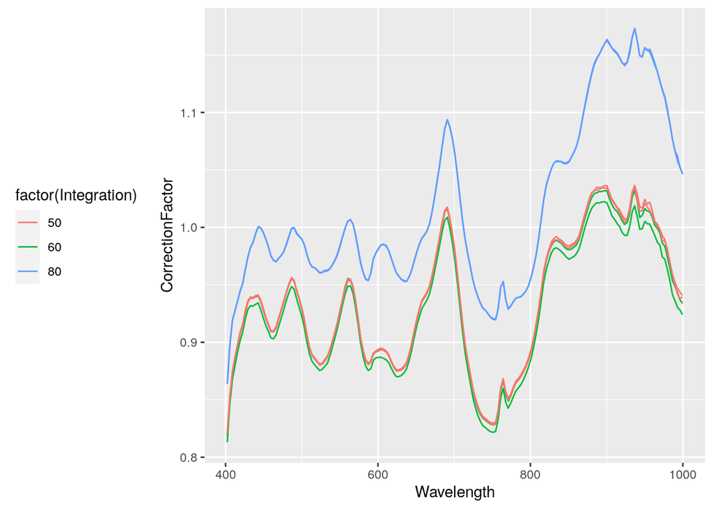

[figure not shown]

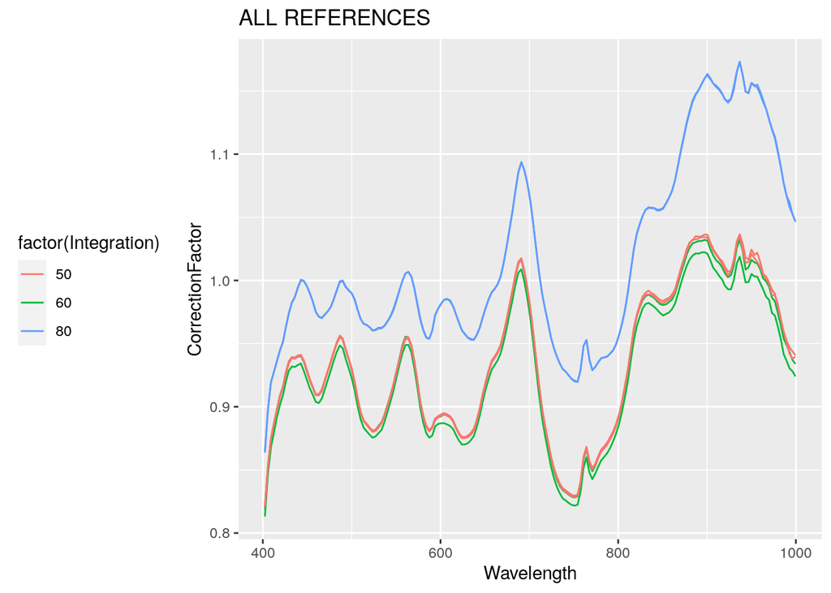

### Apply References

```
## # A tibble: 0 x 20
## # … with 20 variables: spu_filename <chr>, DateTime <dttm>, FileNum <int>,
## #   ScanType <chr>, Integration <dbl>, NumberScans <chr>,
## #   Minimum_wavelength <chr>, Minimum_value <chr>, Maximum_wavelength <chr>,
## #   Maximum_value <chr>, Limits <chr>, Temperature <dbl>, Battery <chr>,
## #   Aux <chr>, DarkscanID <chr>, Remarks <chr>, spu_filename_full <chr>,
## #   Site <chr>, Spectra <list>, Date <date>
```

##### Check Application

| Date | Site | Block | Treatment | Integration | Num_Files |
| --- | --- | --- | --- | --- | --- |
| 2020-07-16 | MAT06 | B1, B2, B3, B4 | THROWAWAY | 120 | 1 |

```
## [1] DARK      REF-maxed REF
## 12 Levels: CT DARK F0.5 F1 F10 F2 F5 GH-CT GH-no-plastic REF ... THROWAWAY
```

#### Reflectance >1

##### Plot Check

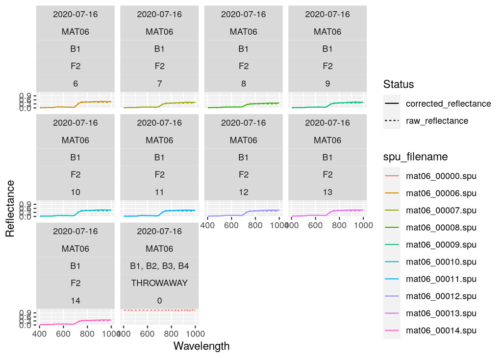